# Creating reproducible reports

A workshop in reproducible research for the R novice

Session 2

Richard Layton

Department of Mechanical Engineering  
Rose-Hulman Institute of Technology  
2016-08-24

## Session 2 agenda

[figure not shown]

What’s in your data science toolbox?

Image courtesy [Pixabay.](https://pixabay.com/en/tools-hammer-saw-shovel-575622/)

Reproducible reports

- Q&A
- Continue the tutorials
- When the data change

Take the next steps

- What tasks have we scripted?
- Plan for reproducibility
- Start your own project

Wrap-up

- Summarize your progress
- Look ahead
- Assess the workshop

# Reproducible reports

- Q&A
- Continue the tutorials
- When the data change

# Principle 1: Blend computing, results, and narrative

Reviewing the tasks we’ve scripted

- import an image file
- read a data file
- create a data table and write it to file
- perform data carpentry to tidy the data
- reshape data from wide to long form
- create a graph and save it to file
- perform a linear regression
- extract relevant results and write to file
- write a reproducible client report

[figure not shown]

## Principle 2: Organize for reproducibility from the beginning

- everything is a script
- every script is connected
- file management is planned
  - directory structure
  - file naming scheme

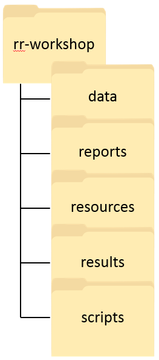

## Managing files

data/

— 007_wide-data.csv

— 01_calibr_data_active-report.csv

— 02_calibr_data-tidy.csv

reports/

— 05_calibr_report.Rmd

— 05_calibr_report.docx

— 05_calibr_report_copy.docx

— 05_calibr_report_to-client_2016-08-24.pdf

resources/

— load-cell-setup-786x989px.png

results/

— 01_calibr_data-wide.csv

— 03_calibr_graph.png

— 04_calibr_outcomes.csv

scripts/

— 01_calibr_data-wide.Rmd

— 02_calibr_data-tidy.Rmd

— 03_calibr_graph.Rmd

— 04_calibr_regression.Rmd

# Two basic princples for reproducible research

Blend computing, results, and narrative

- write everything as a text file
- make file links explicit
- commingle computation and narrative

Organize for reproducibility from the beginning

- plan the directory structure
- plan the file naming scheme

# Back to work

Continue working on the sample calibration report

OR

Start your own reproducible project

# Mystery question 4 (pink)

*Plus-delta on your own progress:*  
$+$ What did you accomplish in the workshop?  
$\Delta$ What could you have done better?

# Looking ahead

Makefiles

- `01_calibr_data-wide.Rmd`
- `02_calibr_data-tidy.Rmd`
- `03_calibr_graph.Rmd`
- `04_calibr_regression.Rmd`
- `05_calibr_report.Rmd`

Other skillz

- use version control from the beginning
- plan workflow with collaborators
- plan the management and structure of data
- create software compendium

# Workshop assessment

Please use the back of the pink sheet.

*Plus-delta on the workshop:*  
$+$ What went well?  
$\Delta$ What could I have done better?